# GRN of E.Coli: Conditional Independencies vs Sample Size

2023-03-09

```r
knitr::opts_chunk$set(echo = TRUE)
```

# Load packages

```r
library(dagitty)
library(lavaan)
library(sna)
library(DOT)
library(igraph)
library(pcalg)
library(SEMgraph)
library(reticulate)
library(dplyr)
library(ggdag)
library(rgbif)
```

# Functions

```r
# Function to create a agrapgh from interaction file

path <- function (GRN){
  relationships <- list()# open the file
  paths <- list()
  # split the line into child and parents
  for (line in 1:nrow(GRN)) {
    line_elements <- strsplit(GRN[line,], ",") [[1]]
    #child <- line_elements[1]
    child <- as.numeric(line_elements[1])
    child <- GeneIDs[child+1]
    Num.regs <- as.numeric(line_elements[2])
    parents <- strsplit(line_elements[3:(2+Num.regs)]," ")
    parents <-lapply(parents,as.numeric)
    parents <- unlist(parents)
    parents <- GeneIDs[parents +1]
    for (parent in parents) {
      if (!(parent %in% names(relationships))) {
        relationships[[parent]] <- list()
      }
      relationships[[parent]] <- c(relationships[[parent]], child)
    }
  }
  #relationships # each child with their parents

  # create the paths
  paths <- list()
  for (parent in names(relationships)) {
    for (child in relationships[[parent]]) {
      path <- child
      current <- child
      while (current %in% names(relationships)) {
        current <- relationships[[current]][[1]]
        path <- paste0(path, "->" ,current)
      }
      path <- paste0(parent,"->",path)
      paths <- c(paths, path)
    }
  }
  return (unlist(paths))
}


# Function to extract simulated data for each cell type
get.data.celltype <- function(df, bins, celltype){
  n.cells <- nrow(df)/bins
  temp <- split( df , cut(1:nrow(df), bins) )[[celltype]]
  if(nrow(temp)==n.cells){
    return(temp)
  }
  else{
    return("number of simulated cells doesn't match with the extracted data")
  }
}



# Function for conditional independence test (compute independencies with at most 3 conditioning variables)
con.ind <- function(df, bins, celltype, g){
  d <- get.data.celltype(df, bins, celltype)
  d <- data.frame(scale(d))
  imp <- Filter(function(x) length(x$Z)<4, impliedConditionalIndependencies(g))
  CI <- localTests( g, d, "cis", R=100, tests=imp, loess.pars=list(span=0.6) )
  return (CI)
}
```

## Load E.coli GRN graph and data

The data are from SERGIO project. The file contain 100 data for 100 genes with 300 cells each with 9 cell types (i.e., conditions)

```r
# Load dot file and GRN interaction file for the GRN grapgh
dot <- read.dot("C:/Projects/GitHub/Sergio_NM/GNW_sampled_GRNs/Ecoli_100_net1.dot") # GRN graph
GRN <- read.table("C:/Projects/GitHub/Sergio_NM/data_sets/De-noised_100G_9T_300cPerT_4_DS1/Interaction_cID_4.txt", quote="\"", comment.char="")

# Load simulated gene expressions
GRN_out <- read.csv("C:/Projects/GitHub/Sergio_NM/data_sets/De-noised_100G_9T_300cPerT_4_DS1/simulated_noNoise_0.csv") # Existing data

# Load gene IDs
GeneIDs <- read.delim("C:/Projects/GitHub/Sergio_NM/GNW_sampled_GRNs/Ecoli_100_net1.dot", header=FALSE)
GeneIDs <-GeneIDs$V2[-c(1,2)][1:100]
GeneIDs <- gsub(';','',GeneIDs)
gene.geneID <- data.frame(cbind(Gene=GeneIDs, ID=0:99))
gene.geneID$ID <- as.numeric(gene.geneID$ID)
gene.geneID
```

```
##     Gene ID
## 1   rutA  0
## 2   rutR  1
## 3   nemA  2
## 4   fepB  3
## 5   rutG  4
## 6   phoP  5
## 7   rutF  6
## 8   rutB  7
## 9   rutE  8
## 10  arcA  9
## 11  ydeA 10
## 12  fadL 11
## 13  rpsJ 12
## 14  yrbL 13
```

[output cut: 86 more lines]

```r
# Master regulators
gene.geneID[gene.geneID$ID %in% c(67,17,56,44,62,93,84),]
```

```
##    Gene ID
## 18 uvrA 17
## 45 metL 44
## 57 astC 56
## 63 betI 62
## 68 slyB 67
## 85 lldD 84
## 94 fadB 93
```

```r
# Load data from Jeremy's DS1.daggity file
grn.dagitty <- read.delim("C:/Projects/GitHub/Sergio_NM/GRN_Analysis/DS1.dagitty", header=FALSE)
```

# Summary of simulated data

```r
#summary(GRN_out)
GRN_out <- t(GRN_out[,-1])
colnames(GRN_out) <- GeneIDs
dim(GRN_out)
```

```
## [1] 2700  100
```

```r
head(GRN_out)
```

```
##        rutA      rutR     nemA     fepB     rutG     phoP     rutF     rutB
## X0 6.323789  5.412827 6.566084 4.315959 4.808177 1.261363 7.773322 3.297296
## X1 6.255952 10.803509 2.062341 3.220587 4.654472 3.966660 7.038059 4.429641
## X2 8.634405  7.477550 5.699295 1.436707 2.742947 4.639661 5.961320 5.201628
## X3 3.410407  8.109471 6.304175 4.618057 7.873641 4.525218 9.354468 4.011371
## X4 8.206440  5.802906 5.783085 1.886708 4.419461 5.200448 5.361131 5.056620
## X5 4.531128  9.167125 4.620637 2.179786 3.770729 3.018360 4.933312 4.895402
##         rutE     arcA      ydeA     fadL      rpsJ      yrbL     hybC     ackA
## X0  6.230673 3.467335 3.9955909 6.623028 0.5962719  3.889734 4.851615 1.258292
## X1  5.021484 2.489936 5.4808803 7.556297 8.7107937  6.893528 8.156457 8.019196
## X2  5.002458 5.811727 3.0063050 2.245308 6.1417164  2.395398 7.224937 1.796438
## X3  5.045061 5.072340 4.0684462 7.864816 8.2713231 10.673488 9.507474 2.742014
## X4 10.739768 5.491959 0.9227441 1.259395 4.1546232  1.965671 8.199573 3.257231
## X5  4.890495 7.063923 0.7842581 5.653942 5.1580766  7.460307 6.666808 2.168091
##         rplB        uvrA       glnG     ddpA      ddpF       fadI       ddpB
## X0  8.351160 1.904576760 3.92524253 6.450551  2.249399  5.6120059 0.07373879
## X1  4.067053 0.055637241 5.13502129 9.927954  6.031032  5.4545780 2.77429352
## X2  5.807817 0.003428475 3.12972678 2.528467  7.038424  6.7006123 3.86625336
## X3  6.927088 0.143417423 5.98926358 7.952369  5.320389 10.0699569 4.69281452
## X4 10.406236 0.229811768 0.06578541 8.170742 11.608337  0.3704817 5.87778994
## X5  1.893240 1.822729010 1.88740329 6.402056  5.134372  4.2378937 2.36178237
##         iraM     ddpD     yeaG     yhdY     borD     appA      ybjG     yhdZ
## X0 0.1785314 6.085564 1.408668 2.533704 2.911792 4.309880  5.563865 6.877042
## X1 1.7518212 6.209545 4.487345 8.222466 1.114350 6.677565  9.603363 5.960870
## X2 4.7460297 8.513192 3.806833 3.722172 4.919972 3.706390  3.905779 7.464634
## X3 4.8994619 5.409935 3.058087 9.288726 4.321873 5.351850 10.900124 7.904669
## X4 3.4421715 8.761106 1.284760 6.333613 4.930921 3.691497  9.751230 3.646623
## X5 5.1545897 7.575619 3.295969 5.921738 4.171708 3.650861  7.017223 9.178825
##        potG       yeaH     ddpX     hybO     phoQ     rutD      rplV      betB
## X0 2.145387 0.91085508 3.172493 4.180564 5.363653 3.195334 3.7313014 0.3186815
## X1 0.987308 6.44397543 7.979662 3.860579 3.781675 1.970655 4.6264645 6.1237856
## X2 3.424913 4.16661862 3.795659 8.192138 1.912272 2.781378 2.6876478 4.3081328
## X3 3.870203 5.89612039 3.070886 2.252414 7.797166 5.373312 0.9676339 2.1879944
## X4 3.123904 0.09484561 3.762969 1.433764 2.833633 3.046724 6.5800348 2.7828307
## X5 1.918822 2.33710317 8.210475 1.171611 5.532219 2.305464 4.5325444 2.1830303
##         astE     hybF     betT      yhdW       tpx      metL     betA     argT
## X0  8.013392 1.309387 6.856651  7.439094  6.512263 0.7827137 3.119044 3.611641
## X1  7.034158 8.471867 4.286487  8.757537 11.290129 0.7224041 5.401379 4.121429
## X2  6.683043 2.451050 2.721077 11.562195  5.484272 0.8357154 3.851387 6.733019
## X3  5.437800 4.991663 5.170315  4.608374 10.990630 0.5796868 4.404444 5.177796
```

[output cut: 43 more lines]

```
## X5  9.037012 1.3446368 8.5176316 10.831959 0.6951989  8.053673 11.754294
##         fadR     rplW     artM       fadB      argI      artJ     rplD     lldR
## X0 3.5826147 5.545133 2.396324 1.03663447 0.7340292 2.9648266 3.159589 6.658100
## X1 0.9970282 2.572927 5.755295 0.95083041 0.7290879 1.8161674 3.441790 3.123296
## X2 0.7895980 4.633947 2.599421 0.68281121 1.9413341 0.4491859 5.414819 4.047340
## X3 1.4828263 8.189255 7.564126 2.40332352 3.1681070 2.1233568 4.475098 4.236098
## X4 0.7519317 4.244940 4.085848 0.03973880 0.1602427 0.6776558 3.932685 3.666389
## X5 0.7535764 7.779660 3.565603 0.07276099 1.3492504 2.2804759 5.873825 6.281462
##         potH      fadA
## X0 11.234700  4.966377
## X1 16.312021  4.496473
## X2 11.429543 10.004112
## X3  8.585354  9.010085
## X4 10.745720  4.657308
## X5 14.108986  3.531936
```

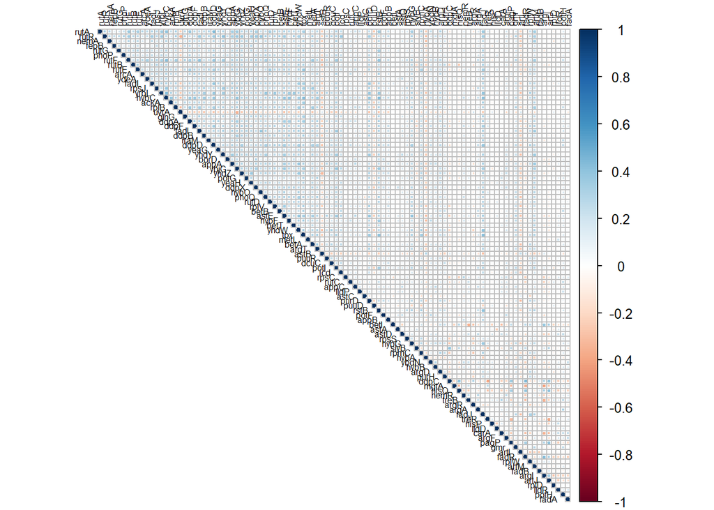

```r
# Pearson's correlation plot (Linear correlation)
res <- cor(GRN_out)
corrplot::corrplot(res,type = "upper", tl.col = "black", tl.cex = 0.5)
```

# The GRN graph

```
## Plot coordinates for graph not supplied! Generating coordinates, see ?coordinates for how to set your own.
```

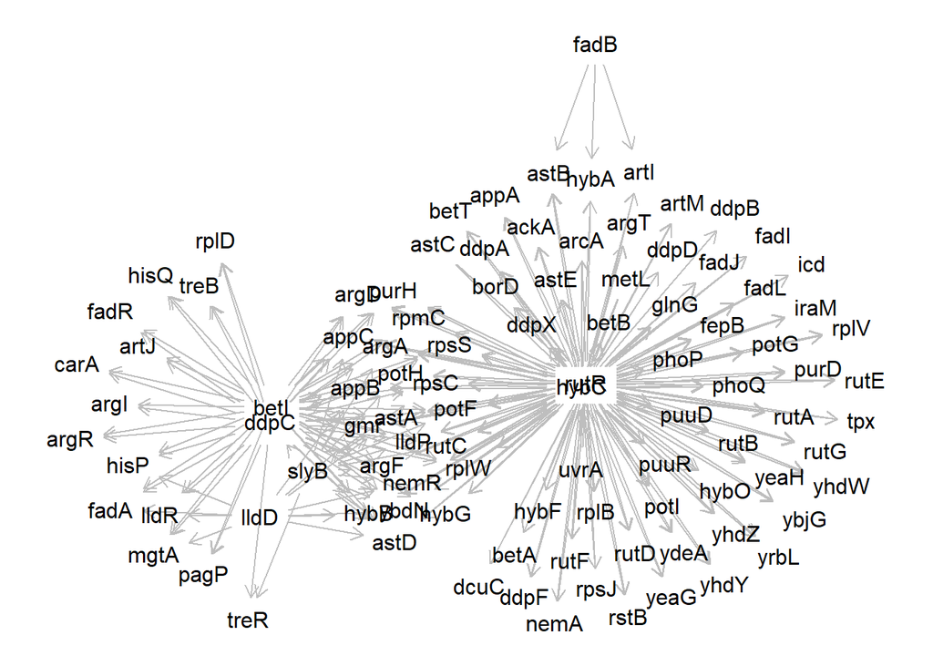

```r
# From Jeremy's daggity file
path_strings <- paste(grn.dagitty$V1,collapse=' ')
g <- dagitty(path_strings )
plot(g)
```

## Conditional independencies

```r
# Conditional independencies
# For each pair of non-adjacent nodes in this graph, the set of variables that d-separates that pair.
# i.e., for each non-adjacent pair of variables, all minimal sets that we can condition on to render that pair independent.
true.ind <- impliedConditionalIndependencies(g, type = "missing.edge", max.results = Inf)
true.ind
```

```
## ackA _||_ appA | hybC, rutR
## ackA _||_ appB | hybC, rutR
## ackA _||_ appC | hybC, rutR
## ackA _||_ arcA | hybC, rutR
## ackA _||_ argA | hybC, rutR
## ackA _||_ argD | hybC, rutR
## ackA _||_ argF | hybC, rutR
## ackA _||_ argI
## ackA _||_ argR
## ackA _||_ argT | hybC, rutR
## ackA _||_ artI | hybC, rutR
## ackA _||_ artJ
## ackA _||_ artM | hybC, rutR
## ackA _||_ astA | hybC, rutR
## ackA _||_ astB | hybC, rutR
## ackA _||_ astC | hybC, rutR
## ackA _||_ astD | hybC, rutR
## ackA _||_ astE | hybC, rutR
## ackA _||_ betA | hybC, rutR
## ackA _||_ betB | hybC, rutR
## ackA _||_ betI
## ackA _||_ betT | hybC, rutR
## ackA _||_ borD | hybC, rutR
## ackA _||_ carA
## ackA _||_ dcuC | hybC, rutR
## ackA _||_ ddpA | hybC, rutR
## ackA _||_ ddpB | hybC, rutR
## ackA _||_ ddpC
## ackA _||_ ddpD | hybC, rutR
## ackA _||_ ddpF | hybC, rutR
## ackA _||_ ddpX | hybC, rutR
## ackA _||_ fadA
## ackA _||_ fadB
## ackA _||_ fadI | hybC, rutR
## ackA _||_ fadJ | hybC, rutR
## ackA _||_ fadL | hybC, rutR
## ackA _||_ fadR
## ackA _||_ fepB | hybC, rutR
## ackA _||_ glnG | hybC, rutR
## ackA _||_ gmr | hybC, rutR
```

[output cut: 4637 more lines]

```
## yeaG _||_ yeaH | hybC, rutR
## yeaG _||_ yhdW | hybC, rutR
## yeaG _||_ yhdY | hybC, rutR
## yeaG _||_ yhdZ | hybC, rutR
## yeaG _||_ yrbL | hybC, rutR
## yeaH _||_ yhdW | hybC, rutR
## yeaH _||_ yhdY | hybC, rutR
## yeaH _||_ yhdZ | hybC, rutR
## yeaH _||_ yrbL | hybC, rutR
## yhdW _||_ yhdY | hybC, rutR
## yhdW _||_ yhdZ | hybC, rutR
## yhdW _||_ yrbL | hybC, rutR
## yhdY _||_ yhdZ | hybC, rutR
## yhdY _||_ yrbL | hybC, rutR
## yhdZ _||_ yrbL | hybC, rutR
```

## Non-linear correlations

From all the existing conditional independencies in the GRN, the proportion of independencies that are shown as conditionally dependent from data is calculated here.

```r
df <- data.frame(GRN_out) # 100 genes with 300 cells with first 9 cell types
```

### For cell type 1 (compute independencies with at most 3 conditioning variables)

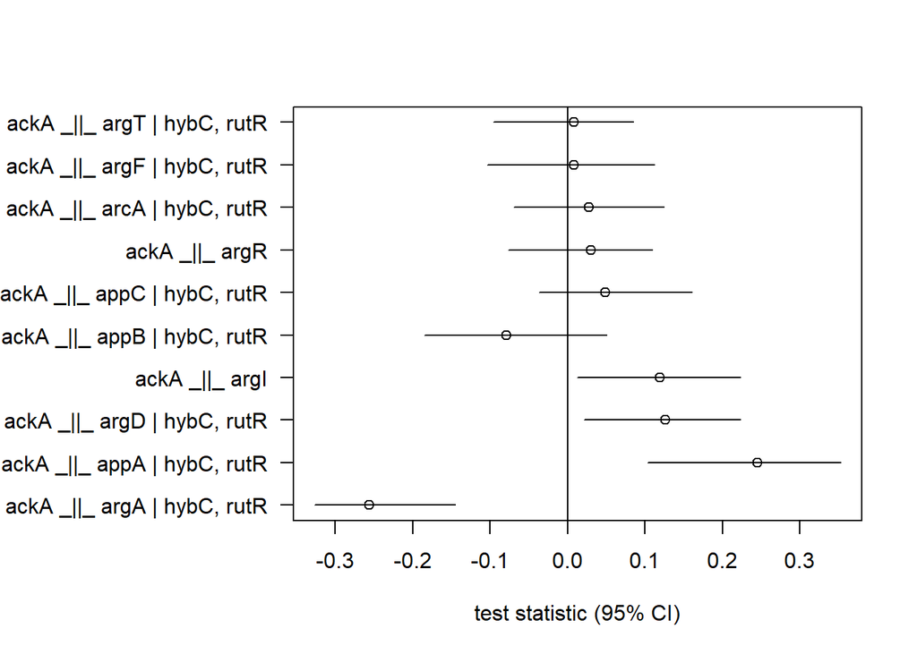

```r
set.seed(1000)
CI <- con.ind(df, 9, 1, g) # Conditional independence test using data from cell type 1
plotLocalTestResults(head(CI,10))
```

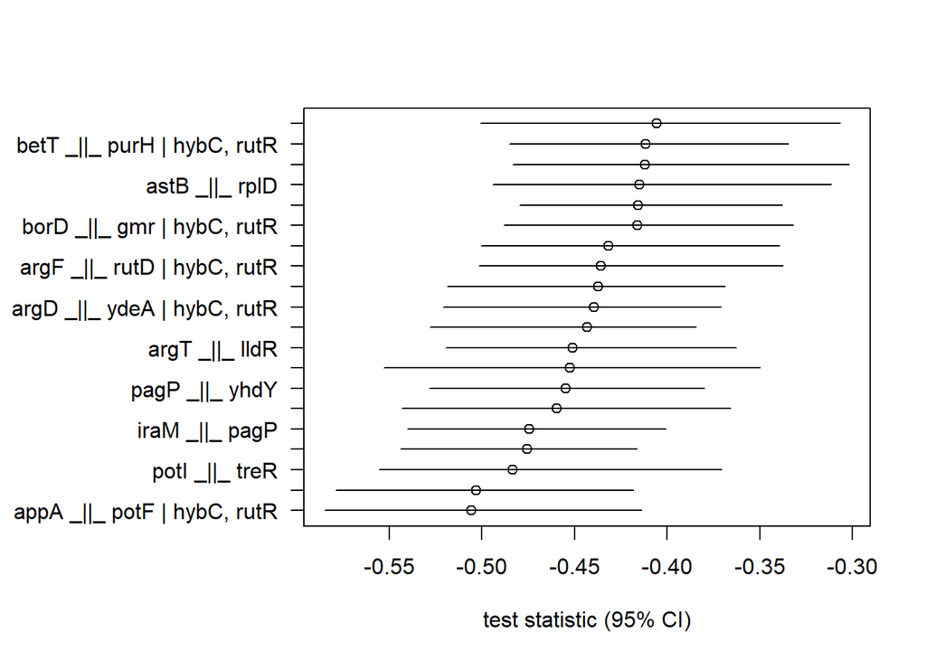

```r
plotLocalTestResults(head(CI[order(CI$estimate),],20)) # The top 20 that deviates from conditional independence
```

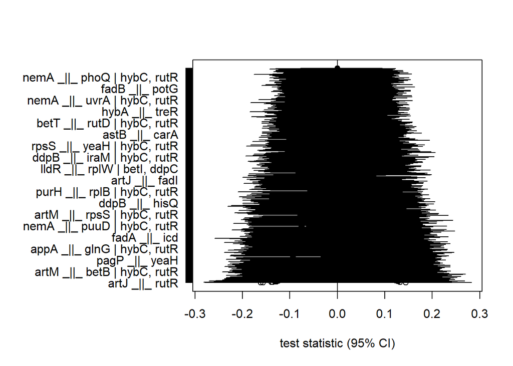

```r
ind <- CI[(CI$`2.5%` <0 & CI$`97.5%`>0),]
dep <- CI[!(CI$`2.5%` <0 & CI$`97.5%`>0),]

# Plot the conditional independencies that we were not able to prove to be dependent (we cannot conclude them to be independent: do not reject null hypothesis that beta=0)
plotLocalTestResults(ind)
```

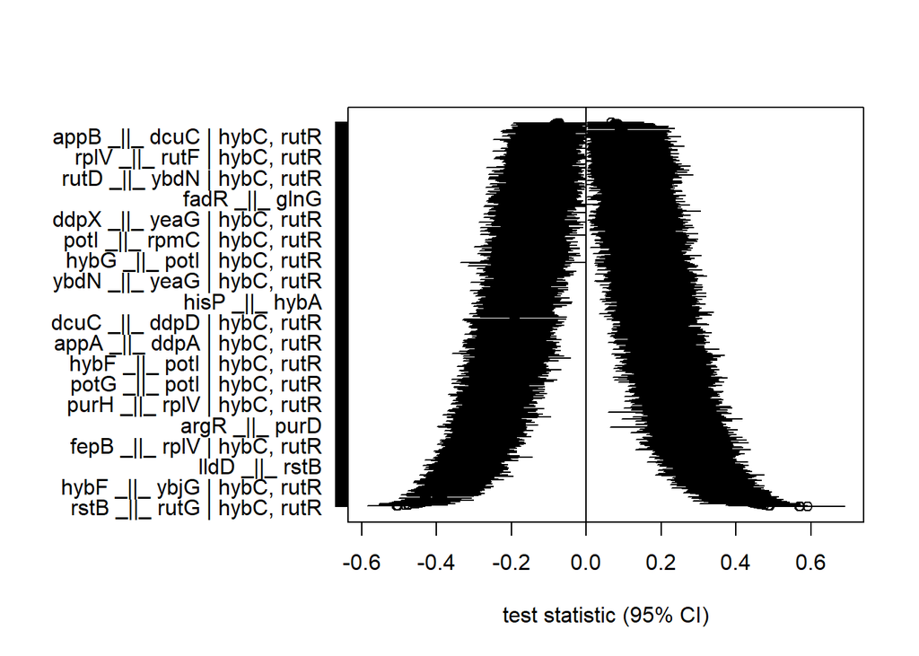

```r
# Plot the conditional independencies that we prove to be dependent
plotLocalTestResults(dep)
```

```r
# When sample size increases the probability of detecting dependencies increases.
p <- nrow(dep)/(nrow(dep)+nrow(ind))
p
```

```
## [1] 0.5403838
```

### For cell type 2 (compute independencies with at most 3 conditioning variables)

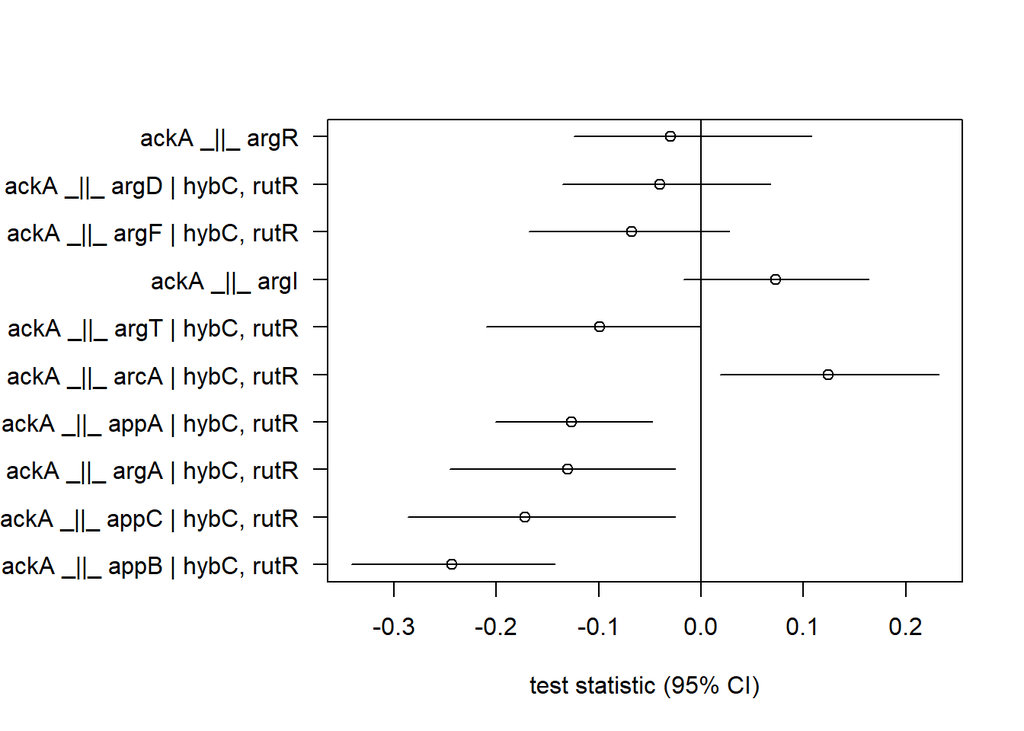

```r
# Compute independencies with at most 3 conditioning variables
set.seed(1000)
CI <- con.ind(df, 9, 2, g) # Conditional independence test using data from cell type 2
plotLocalTestResults(head(CI,10))
```

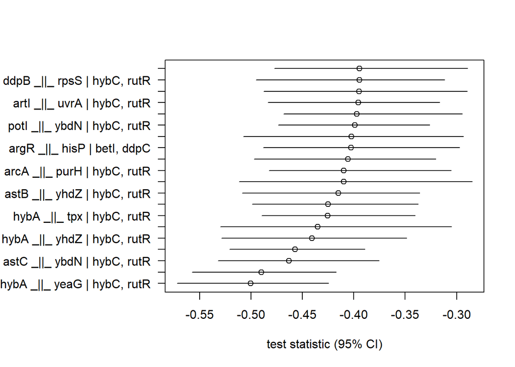

```r
plotLocalTestResults(head(CI[order(CI$estimate),],20)) # The top 20 that deviates from conditional independence
```

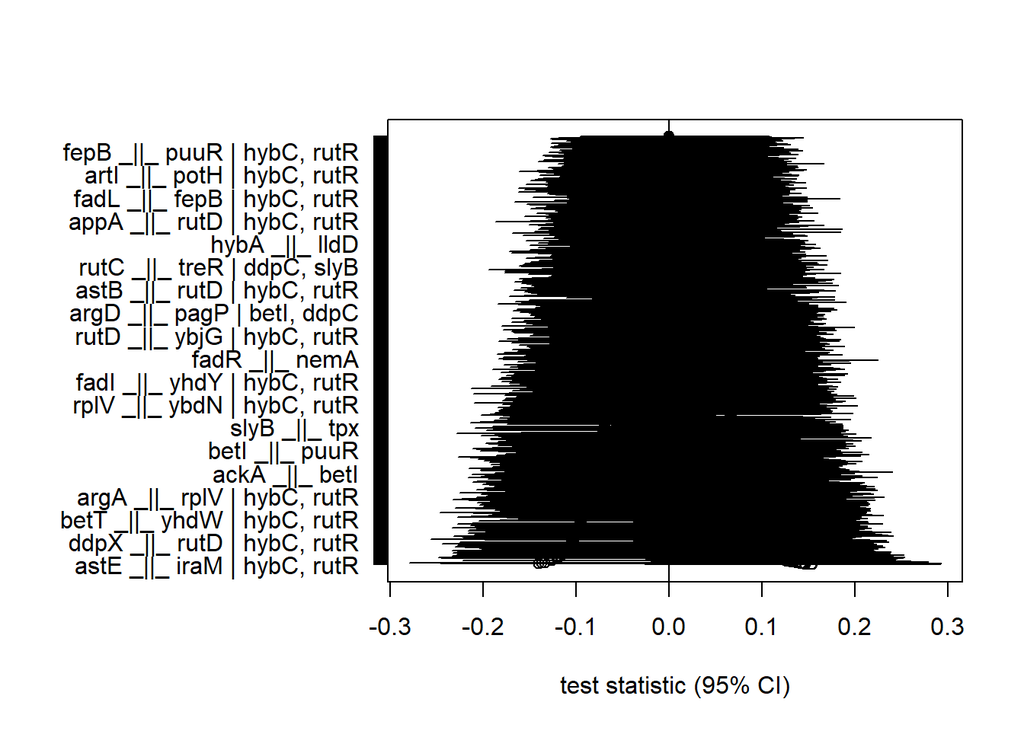

```r
ind <- CI[(CI$`2.5%` <0 & CI$`97.5%`>0),]
dep <- CI[!(CI$`2.5%` <0 & CI$`97.5%`>0),]

# Plot the conditional independencies that we were not able to prove to be dependent (we cannot conclude them to be independent: do not reject null hypothesis that beta=0)
plotLocalTestResults (ind)
```

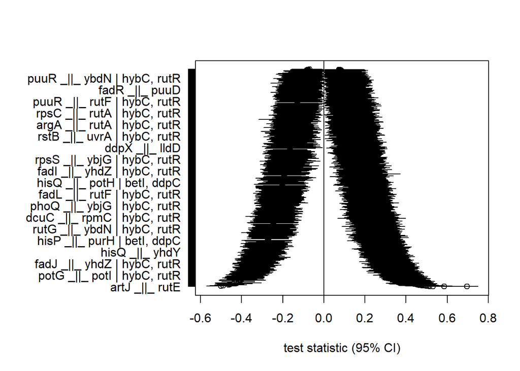

```r
# Plot the conditional independencies that we prove to be dependent
plotLocalTestResults (dep)
```

```r
# When sample size increases the probability of detecting dependencies increases.
p <- nrow(dep)/(nrow(dep)+nrow(ind))
p
```

```
## [1] 0.5468541
```

### For cell type 3 (compute independencies with at most 3 conditioning variables)

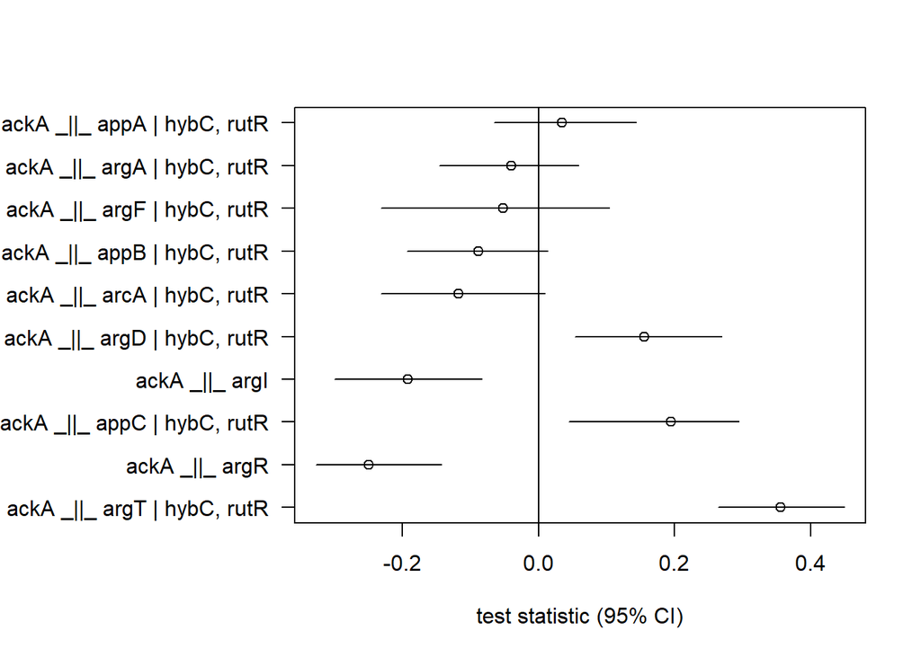

```r
# Compute independencies with at most 3 conditioning variables
set.seed(1000)
CI <- con.ind(df, 9, 3, g) # Conditional independence test using data from cell type 2
plotLocalTestResults(head(CI,10))
```

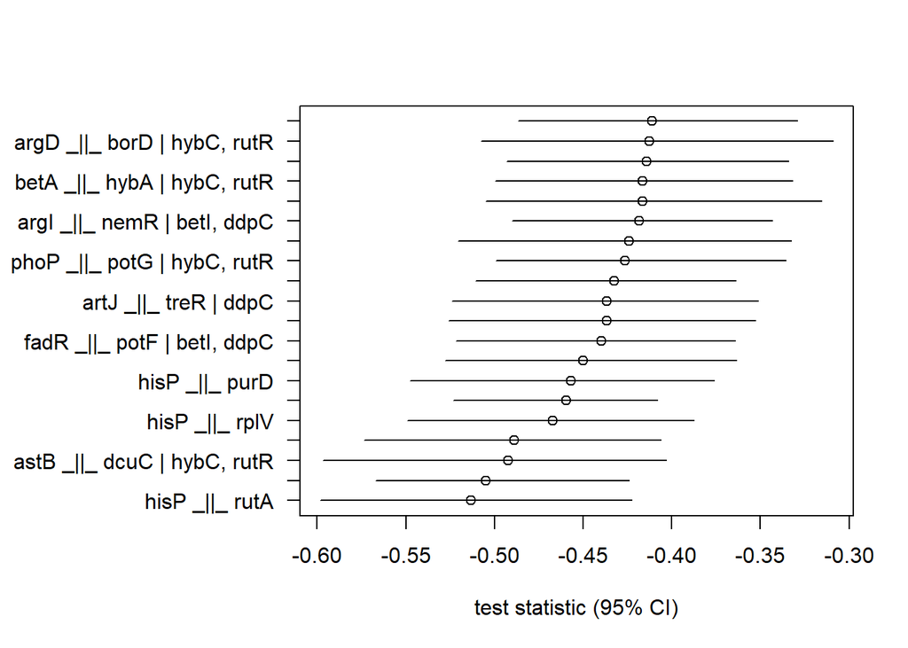

```r
plotLocalTestResults(head(CI[order(CI$estimate),],20)) # The top 20 that deviates from conditional independence
```

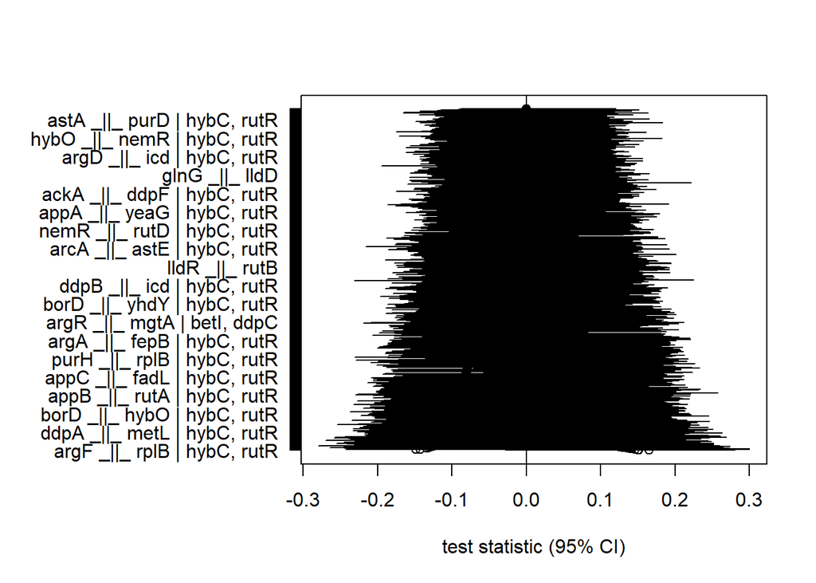

```r
ind <- CI[(CI$`2.5%` <0 & CI$`97.5%`>0),]
dep <- CI[!(CI$`2.5%` <0 & CI$`97.5%`>0),]

# Plot the conditional independencies that we were not able to prove to be dependent (we cannot conclude them to be independent: do not reject null hypothesis that beta=0)
plotLocalTestResults (ind)
```

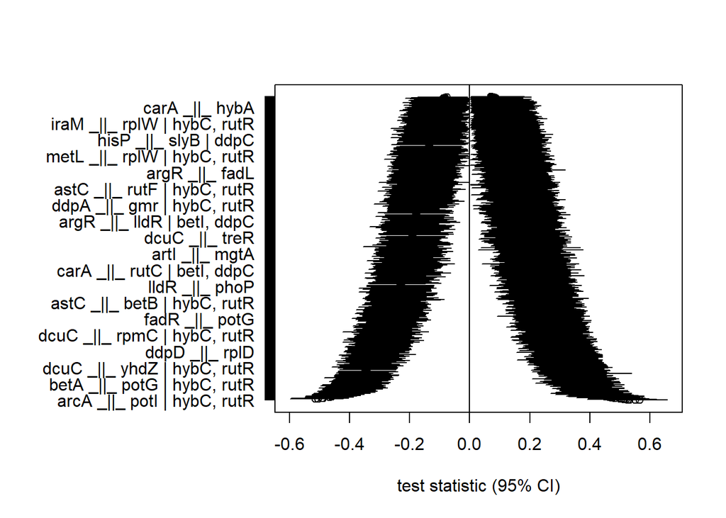

```r
# Plot the conditional independencies that we prove to be dependent
plotLocalTestResults (dep)
```

```r
# When sample size increases the probability of detecting dependencies increases.
p <- nrow(dep)/(nrow(dep)+nrow(ind))
p
```

```
## [1] 0.5731816
```

### For cell type 4 (compute independencies with at most 3 conditioning variables)

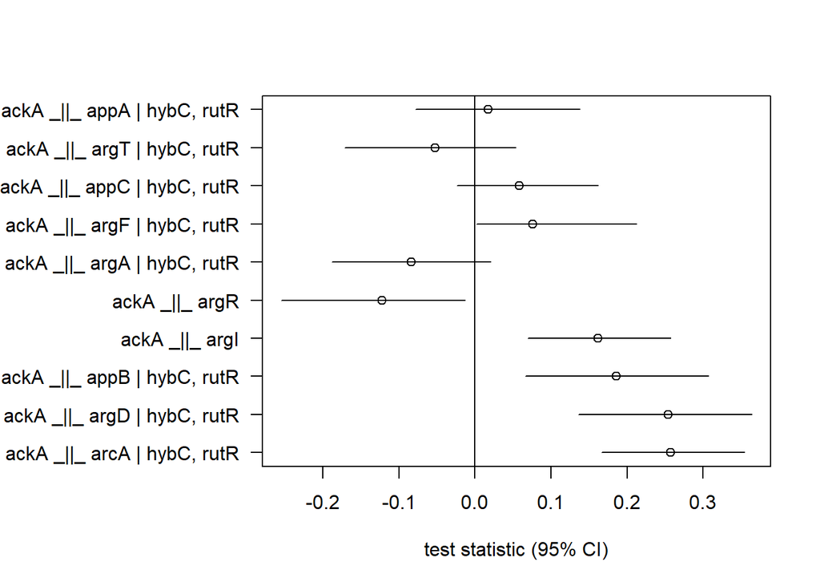

```r
# Compute independencies with at most 3 conditioning variables
set.seed(1000)
CI <- con.ind(df, 9, 4, g) # Conditional independence test using data from cell type 2
plotLocalTestResults(head(CI,10))
```

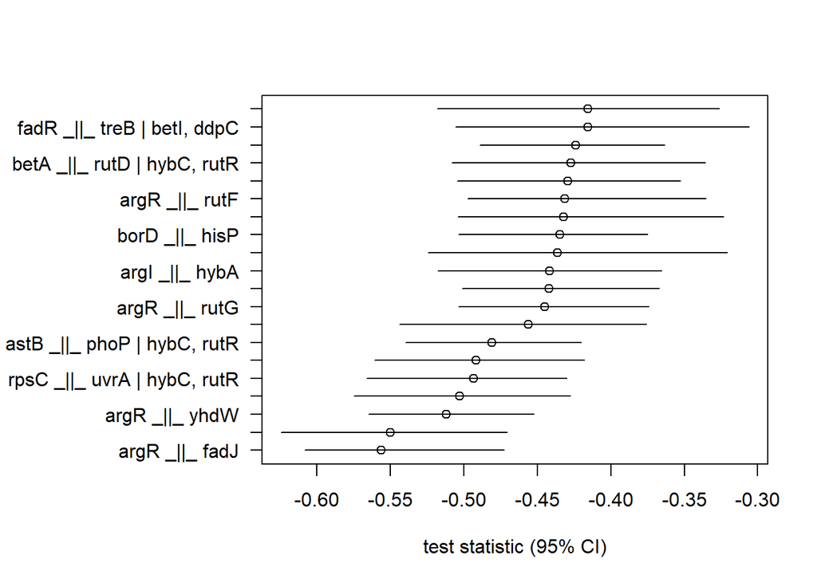

```r
plotLocalTestResults(head(CI[order(CI$estimate),],20)) # The top 20 that deviates from conditional independence
```

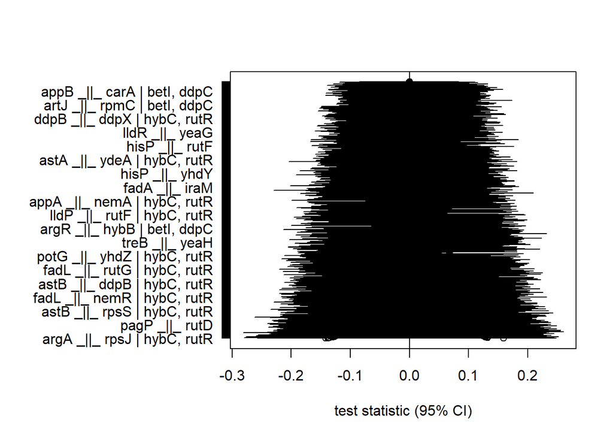

```r
ind <- CI[(CI$`2.5%` <0 & CI$`97.5%`>0),]
dep <- CI[!(CI$`2.5%` <0 & CI$`97.5%`>0),]

# Plot the conditional independencies that we were not able to prove to be dependent (we cannot conclude them to be independent: do not reject null hypothesis that beta=0)
plotLocalTestResults (ind)
```

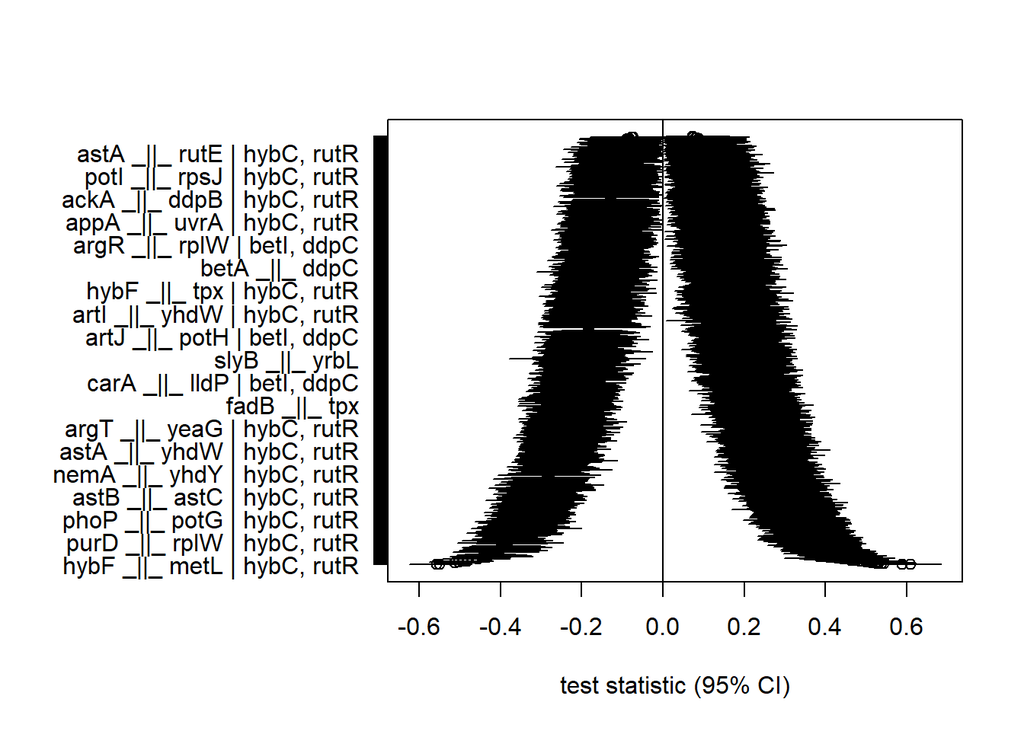

```r
# Plot the conditional independencies that we prove to be dependent
plotLocalTestResults (dep)
```

```r
# When sample size increases the probability of detecting dependencies increases.
p <- nrow(dep)/(nrow(dep)+nrow(ind))
p
```

```
## [1] 0.5756359
```

### For cell type 5 (compute independencies with at most 3 conditioning variables)

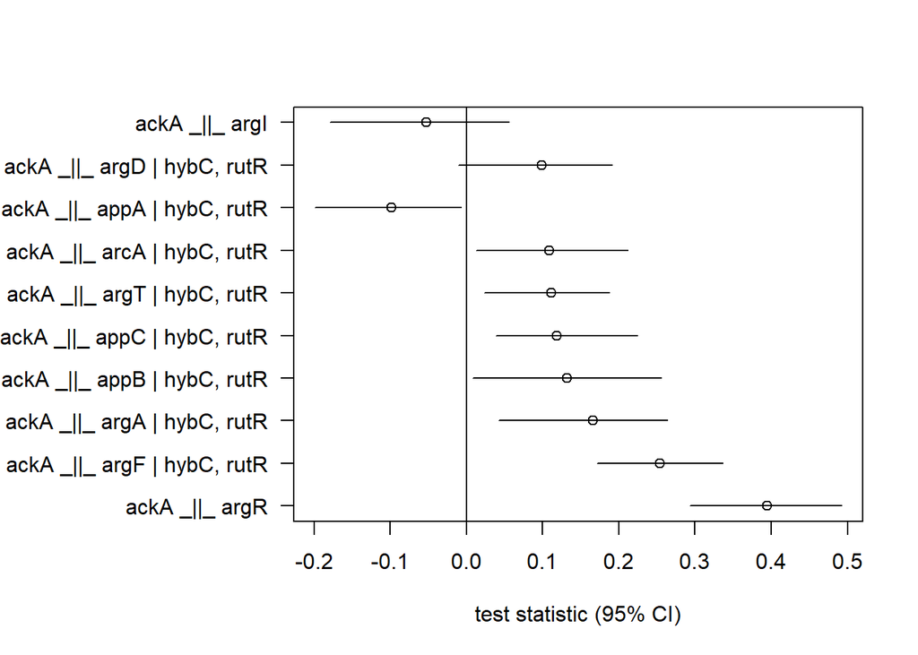

```r
# Compute independencies with at most 3 conditioning variables
set.seed(1000)
CI <- con.ind(df, 9, 5, g) # Conditional independence test using data from cell type 2
plotLocalTestResults(head(CI,10))
```

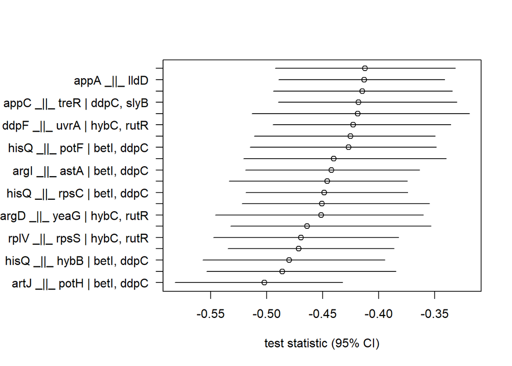

```r
plotLocalTestResults(head(CI[order(CI$estimate),],20)) # The top 20 that deviates from conditional independence
```

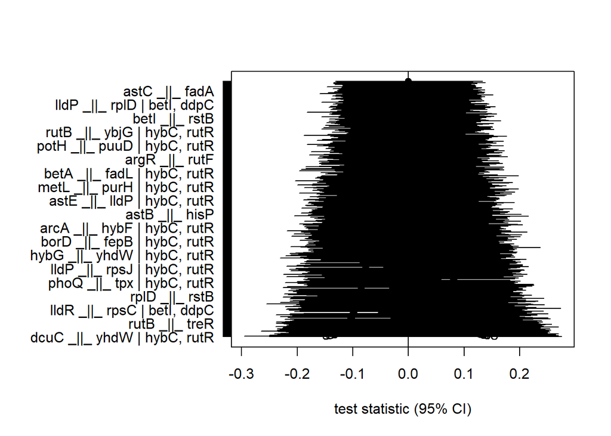

```r
ind <- CI[(CI$`2.5%` <0 & CI$`97.5%`>0),]
dep <- CI[!(CI$`2.5%` <0 & CI$`97.5%`>0),]

# Plot the conditional independencies that we were not able to prove to be dependent (we cannot conclude them to be independent: do not reject null hypothesis that beta=0)
plotLocalTestResults (ind)
```

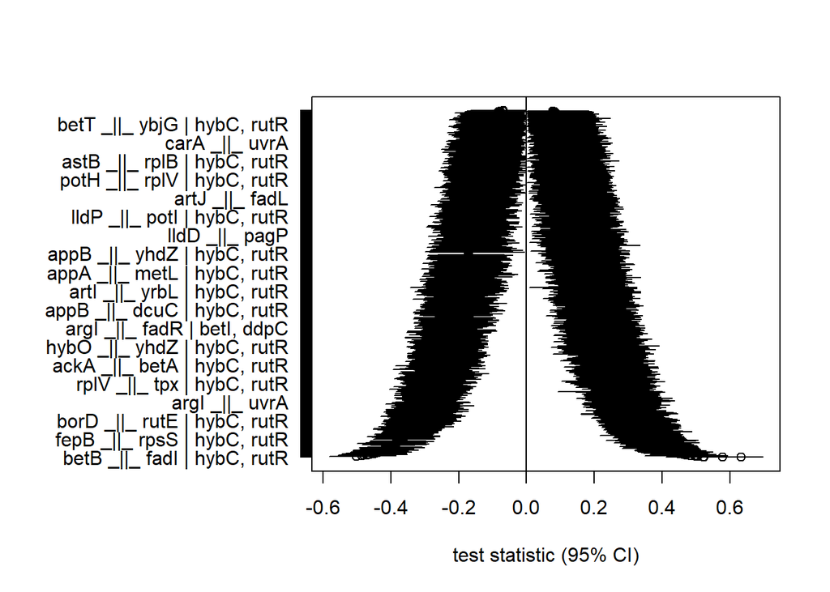

```r
# Plot the conditional independencies that we prove to be dependent
plotLocalTestResults (dep)
```

```r
# When sample size increases the probability of detecting dependencies increases.
p <- nrow(dep)/(nrow(dep)+nrow(ind))
p
```

```
## [1] 0.5671575
```

### For cell type 6 (compute independencies with at most 3 conditioning variables)

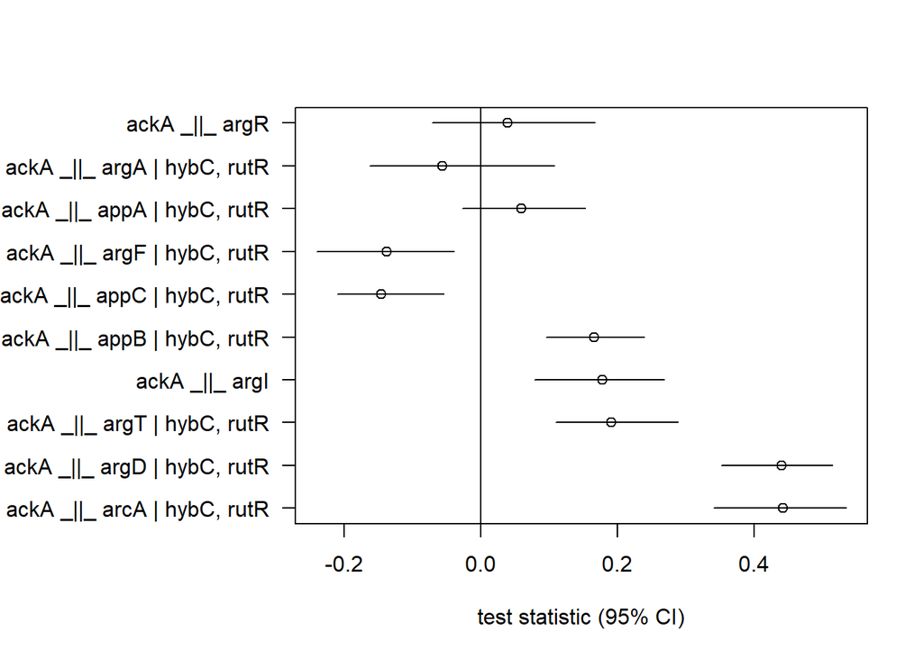

```r
# Compute independencies with at most 3 conditioning variables
set.seed(1000)
CI <- con.ind(df, 9, 6, g) # Conditional independence test using data from cell type 2
plotLocalTestResults(head(CI,10))
```

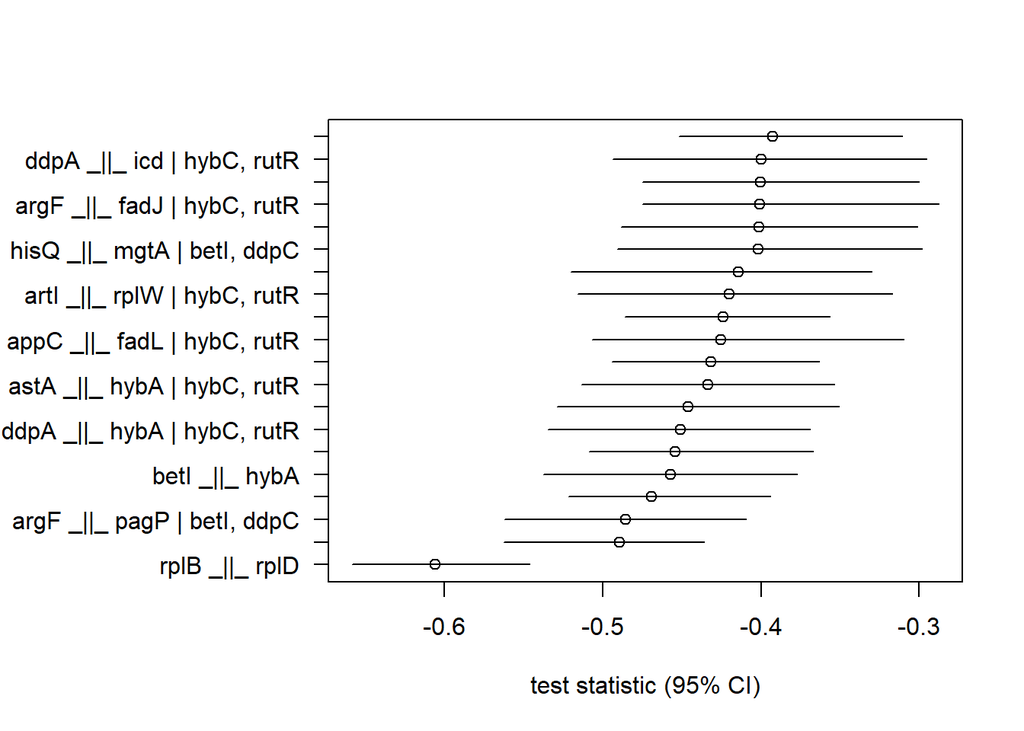

```r
plotLocalTestResults(head(CI[order(CI$estimate),],20)) # The top 20 that deviates from conditional independence
```

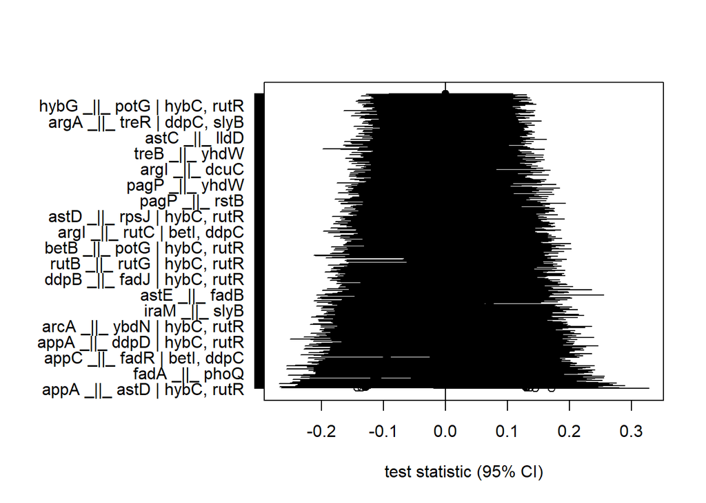

```r
ind <- CI[(CI$`2.5%` <0 & CI$`97.5%`>0),]
dep <- CI[!(CI$`2.5%` <0 & CI$`97.5%`>0),]

# Plot the conditional independencies that we were not able to prove to be dependent (we cannot conclude them to be independent: do not reject null hypothesis that beta=0)
plotLocalTestResults (ind)
```

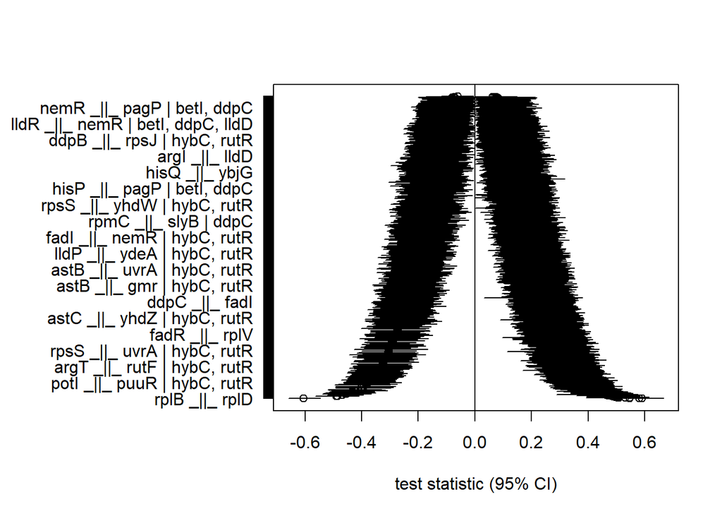

```r
# Plot the conditional independencies that we prove to be dependent
plotLocalTestResults (dep)
```

```r
# When sample size increases the probability of detecting dependencies increases.
p <- nrow(dep)/(nrow(dep)+nrow(ind))
p
```

```
## [1] 0.5533244
```

### For cell type 7 (compute independencies with at most 3 conditioning variables)

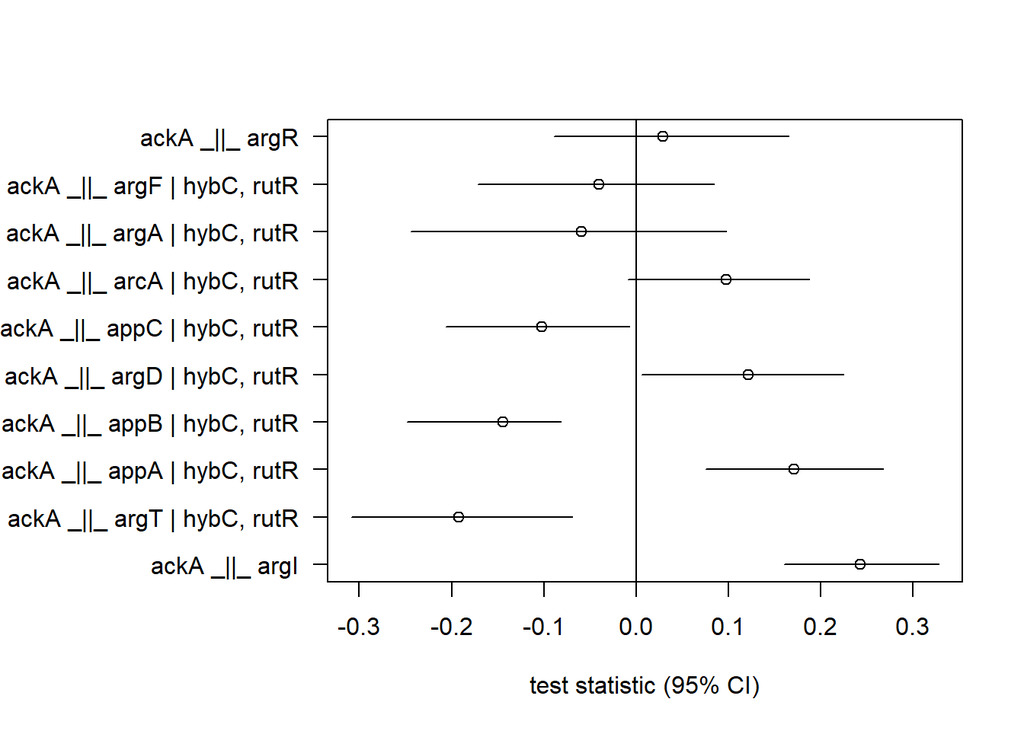

```r
# Compute independencies with at most 3 conditioning variables
set.seed(1000)
CI <- con.ind(df, 9, 7, g) # Conditional independence test using data from cell type 2
plotLocalTestResults(head(CI,10))
```

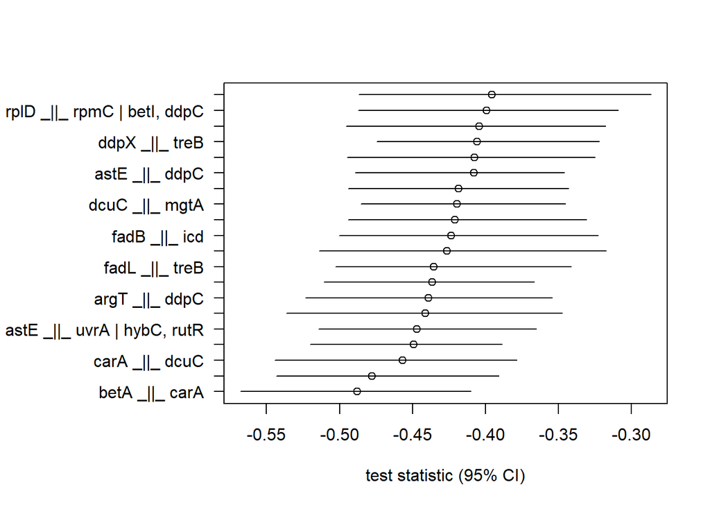

```r
plotLocalTestResults(head(CI[order(CI$estimate),],20)) # The top 20 that deviates from conditional independence
```

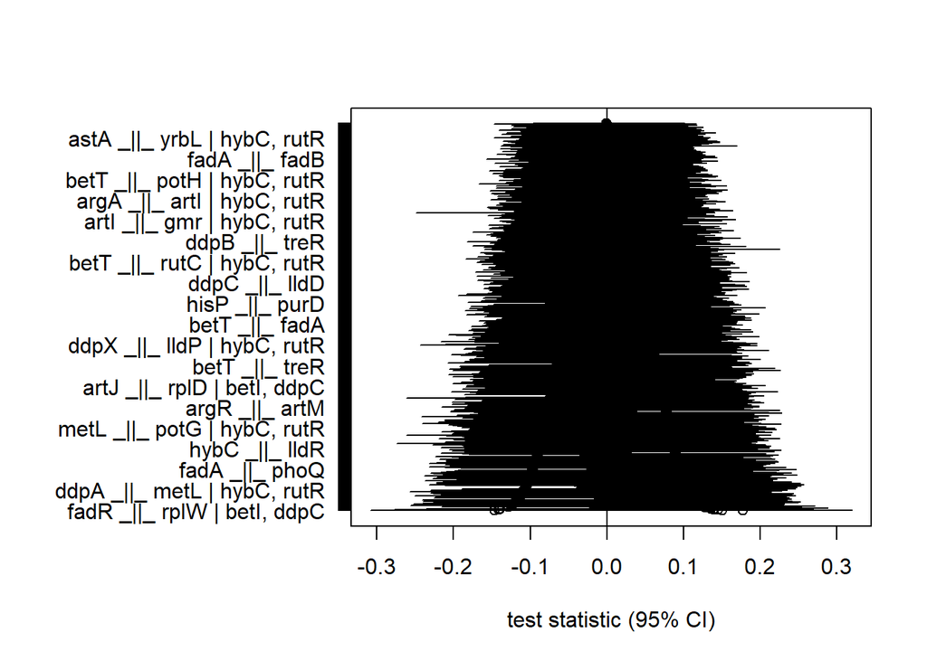

```r
ind <- CI[(CI$`2.5%` <0 & CI$`97.5%`>0),]
dep <- CI[!(CI$`2.5%` <0 & CI$`97.5%`>0),]

# Plot the conditional independencies that we were not able to prove to be dependent (we cannot conclude them to be independent: do not reject null hypothesis that beta=0)
plotLocalTestResults (ind)
```

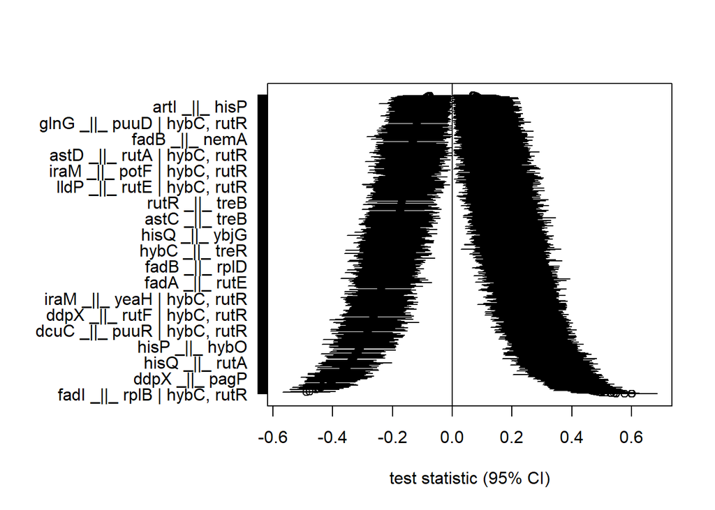

```r
# Plot the conditional independencies that we prove to be dependent
plotLocalTestResults (dep)
```

```r
# When sample size increases the probability of detecting dependencies increases.
p <- nrow(dep)/(nrow(dep)+nrow(ind))
p
```

```
## [1] 0.5832218
```